# Introduction

Adam La Caze

Semester 1, 2024

# Objectives, Set-up and Expectations

## PHRM3031 Objectives

After completing this course you should be able to:

1. Identify the components forming an answerable research question and describe how to search the literature
2. Describe various study designs and be able to discuss the advantages and disadvantages of each in specific circumstances
3. Critically appraise original clinical research articles in the context of evidence based practice (EBP)
4. Calculate clinically relevant measures of effect to assist in the interpretation and application of evidence
5. Demonstrate an ability to apply the principles of clinical epidemiology relevant to pharmacy practice and in a public health context
6. Apply and communicate evidence of treatment effects focused on an individual patient

## Course set-up

- PHRM3031 is a 1-unit course. You should expect to spend approximately 5 hours a week on the course

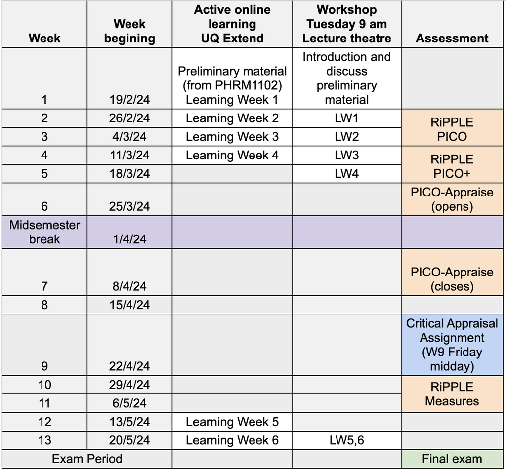

## Approaching the course

**Active online learning**

- Use the activities as learning activities *and* as feedback on how you are travelling
- Being able to read, interpret and apply clinical research is a key objective of the course

**Workshops**

- Attend in person (recorded, but these are a secondary resource)
- Complete the active online learning activities *prior* to the workshop

## Course Resources

**Blackboard**

information, assessment submission regarding the course (lectures, tutorials, assessment)

**Electronic Course Profile (ECP)**

information on assessment and rules.

**[UQ Extend](https://extend.uq.edu.au/courses/course-v1:UQ+PHRM3031+7420_23805/course/)**

Active online learning activities

**RiPPLE**

active personalised learning tool; create and moderate resources

**Ed Discussion Board**

use Ed Discussion Board for all questions and discussion related ot the course

**Reading List**

central reading list for course resources and RiPPLE activity

## Expectations

- Participate in in-person workshops and in the discussion board
- Come to the workshops with any questions you have from the week’s learning activities

## RiPPLE: create and moderate resources

- 4 RiPPLE rounds, each lasting 2 weeks. Each round asks you to *create* and *moderate* learning resources
- First three rounds involve reading a paper and providing: PICO, PICO-plus statement of results, PICO-appraise (brief appraisal of the paper) [create 1, moderate 2 each round]
- Round 4 create questions or other resource to assess the calculation or interpretation of measures of effect [create 2, moderate 2]
- Each round is worth 5% of the course; total weight 20%
- Create your resources in the first week of the round, moderate in the second
- Your resource and moderation need to be effective (i.e. your resource needs to pass moderation and your moderation needs to be more than “this is good”—say why it is good or how it could be improved)

## Critical Appraisal Assignment

- You will receive a published randomized trial before Monday in Week 8 and your critical appraisal is due midday Friday in Week 9
- The assignment is worth 40% of the grade for PHRM3031.
- The rubric used to assess the assignment is available on Blackboard and the ECP.
- Word limit 1000 words

## Template

1. Structured summary
2. Critical appraisal: internal validity
3. Clinically relevant results
4. Implications for practice (Critical appraisal: external validity)

## Written Exam

- When: the written exam is held in the exam period at the end of the semester
- Duration: 1 hour (10 minutes reading time)
- Range of different question types: MCQ, multiple answer, short answer, problem solving
- Content: is taken from lectures and tutorials

The exam is an on-campus invigilated exam using [Inspera](https://web.library.uq.edu.au/library-services/it/learnuq-blackboard-help/inspera-assessment)

## Grades

[output not shown]

To pass PHRM3031 you need to achieve a **total mark $\ge$ 50%**

# Evidence based practice

## What is evidence-based practice?

## Covid-19

- How do we know vaccines work?
- How do we *know* ivermectin and hydroxychloroquine don’t?
- How did we learn about the role of corticosteriods in supportive care?

> You are not a horse. You are not a cow. Seriously, y'all. Stop it. https://t.co/TWb75xYEY4

## Evidence based medicine (EBM)

> Evidence based medicine is the conscientious, explicit, and judicious use of current best evidence in making decisions about the care of individual patients.

Sackett et al. (1996)

## Benefits of EBM

1. EBM makes clear what counts as an appropriate justification for treatment decisions: **evidence**
2. EBM provides (or has contributed to) excellent resources for teaching applied clinical epidemiology, critically appraising research (especially RCTs), reporting research, …

The [Oxford’s Centre for Evidence-based Medicine](https://www.cebm.net/category/ebm-resources/tools/) provides a great repository for many of these tools.

## The practice of EBM (Straus 2019)

1. Convert the need for information into an answerable question: **PICO**
2. Find the **best evidence** to answer the question
3. Critically appraise that evidence for **validity**, **impact** and **applicability**
4. Integrate the critical appraisal with clinical expertise and the patient’s unique biology, values and circumstances: **Make a decision**
5. **Evaluate** the effectiveness and efficiency of your decisions

## Clinical Questions (Step 1)

**Background Questions**

Ask for general information on a disease or medicine. *What causes vasovagal syncope? How does paracetamol relieve pain?*

**Foreground Questions**

Ask a specific question about the effect of an intervention in a particular group of patients. *Is regular paracetamol as effective as an NSAID for pain relief in patients with osteoarthritis?*

## PICO (Step 1)

PICO questions

|  | Clinical Question | Critical Appraisal |
| --- | --- | --- |
| Participants | What are the key characteristics of the patient(s) | Who was recruited to the study? What were the inclusion/exclusion criteria? Who participated? |
| Intervention | What is the intervention under consideration | What intervention did the treatment group receive? |
| Comparator | What is the comparator, control, or usual alternative | What did the control or placebo group receive? |
| Outcome | What is the patient-relevant outcome? (or society-relevant outcome?) | What was the primary outcome of the trial? |

## EBM Levels of evidence (Step 2)

This is a summary of Oxford Center for Evidence-based Medicine’s (2011) levels of evidence for assessing drug benefits. The document provides guidance for grading evidence higher or lower based on methodological considerations and effect sizes.

| Levels | Treatment benefits |
| --- | --- |
| 1 | Systematic review of randomized controlled trials, n-of-1 studies |
| 2 | Randomized controlled trial or observational studies with dramatic effect |
| 3 | Non-randomized controlled cohort of follow-up study with sufficient numbers |
| 4 | Case-series, case-control, or historically controlled studies |
| 5 | Mechanism-based reasoning |

## Critically appraise the evidence (Step 3)

At its most simple, critical appraisal is a matter of reading the study and assessing the degree to which

1. you believe the results, and
2. you can apply the results in your practice

# Clinical epidemiology

## Important causal questions

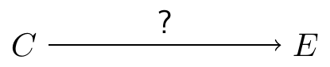

- What are the effects of giving drug $A$ to this patient/population?
- Could the effect we are observing in this patient/population be caused by drug $B$?

## Therapeutic Decisions and Efficacy/Effectiveness

**Population therapeutic decision**

Do the benefits of the intervention outweigh the harms in a defined population of patients?

**Individual therapeutic decision**

Do the benefits of the intervention outweigh the harms in a specific patient?

**Efficacy**

Does the intervention possess the proposed benefits in a defined (and often experimental) population?

**Effectiveness**

Does the intervention possess the proposed benefits in patients under routine care?

## Clinical epidemiology

> Clinical epidemiology is the science of making predictions about individual patients by counting clinical events—death, disease, discomfort, disability, dissatisfaction—in groups of similar patients and using strong scientific methods to ensure that the predictions are accurate.

Fletcher (2021, 3)

## Study design

**Tea-drinker**

You know a tea drinker who believes they can tell whether or not milk was added before the tea.

Design a simple study to determine whether this is true.

**Coin of unknown bias**

You have a coin that you suspect may not be fair (i.e. the chance of Heads on any one toss might not be half).

Design a simple study to determine whether the coin is fair.

# Why randomised trials?

## Why randomised trials

- Minimise the effect of confounders on the assessment of whether a treatment works
  - Random allocation is superior to alternatives in providing groups in which confounders are (roughly) evenly distributed (whether known or unknown)
- Random allocation aids statistical analysis
- Prospective (randomised) studies permit the use of additional methods to reduce bias (masking and appropriate control)

# Why cohort and case control studies?

## Why cohort and case control studies

- de Abajo, Rodríguez, and Montero (1999) conducted a case control study to first identify an association between SSRIs, NSAIDs and gastrointestinal bleeding
- The investigators reviewed 1899 cases of upper gastrointestinal bleeding or ulcer perforation
- 10,000 controls were matched for age, sex and year that the case was identified
- SSRI users were more likely to experience upper GI bleeding (adjusted relative risk 3.0, 95% CI 2.1–4.4)
- SSRI users taking NSAIDs were much more likely to experience upper GI bleeding (adjusted relative risk 15.6, 95% CI 6.6–36.6)

## PICO

| PICO | Clinical Question | Critical Appraisal |
| --- | --- | --- |
| Participants | What are the key characteristics of the patient(s) | Who was recruited to the study? What were the inclusion/exclusion criteria? Who participated? |
| Intervention | What is the intervention under consideration | What intervention did the treatment group receive? |
| Comparator | What is the comparator, control, or usual alternative | What did the control or placebo group receive? |
| Outcome | What is the patient-relevant outcome? (or society-relevant outcome?) | What was the primary outcome of the trial? |

## References

Abajo, F J de, L A Rodríguez, and D Montero. 1999. “Association Between Selective Serotonin Reuptake Inhibitors and Upper Gastrointestinal Bleeding: Population Based Case-Control Study.” *British Medical Journal (Clinical Research Ed.)* 319 (7217): 1106–9. https://doi.org/10.1136/bmj.319.7217.1106.

Fletcher, Grant S. 2021. *Clinical epidemiology: the essentials / Grant S. Fletcher.* Sixth edition. Essentials (Philadelphia, Pa.). Philadelphia: Wolters Kluwer, Lippincott Williams & Wilkins/Wolters Kluwer.

Sackett, David L, W. M C Rosenberg, J A Muir Gray, R B. Haynes, and W Scott Richardson. 1996. “Evidence Based Medicine: What It Is and What It Isn’t.” *BMJ* 312 (7023): 71–72. https://doi.org/10.1136/bmj.312.7023.71.

Straus, Sharon E. 2019. *Evidence-based medicine: how to practice and teach EBM / Sharon E. Straus, Paul Glasziou, W. Scott Richardson, R. Brian Haynes ; with contributions by Reena Pattani, Areti Angeliki Veroniki.* Fifth edition. Edinburgh, Edinburgh ; London ; New York: Elsevier.